# Dashboard

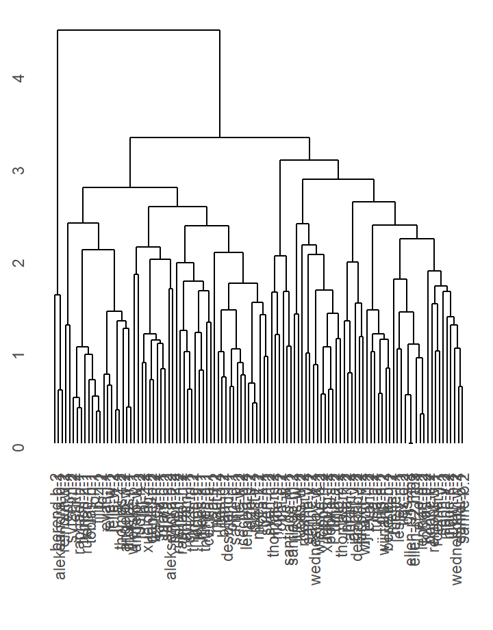

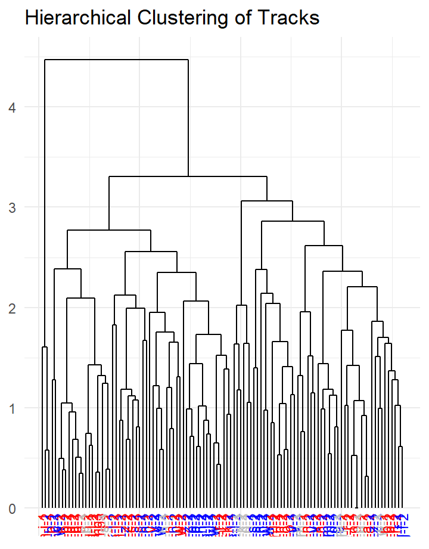

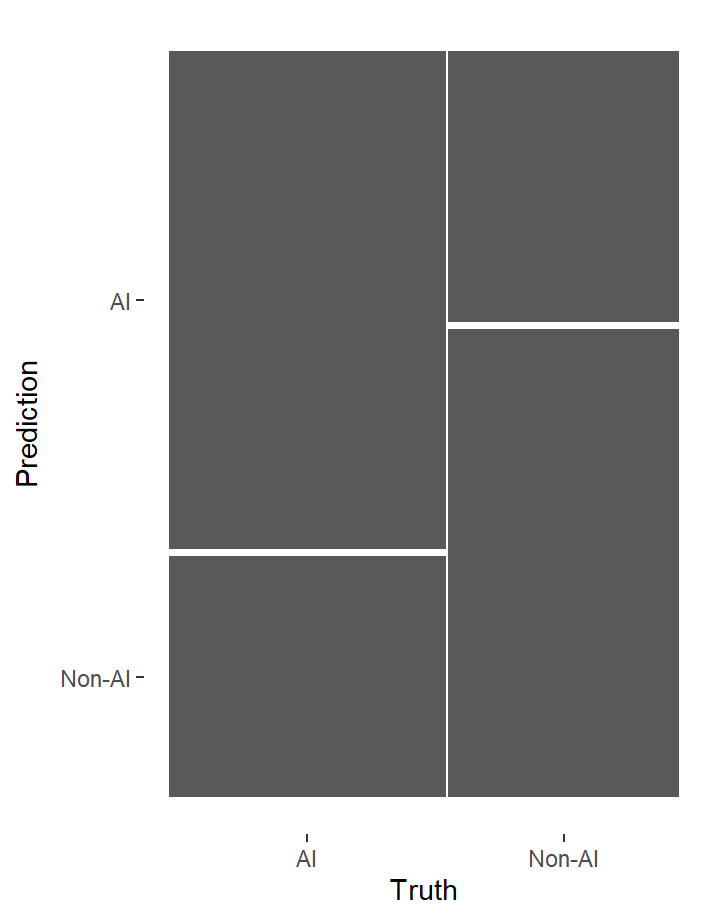

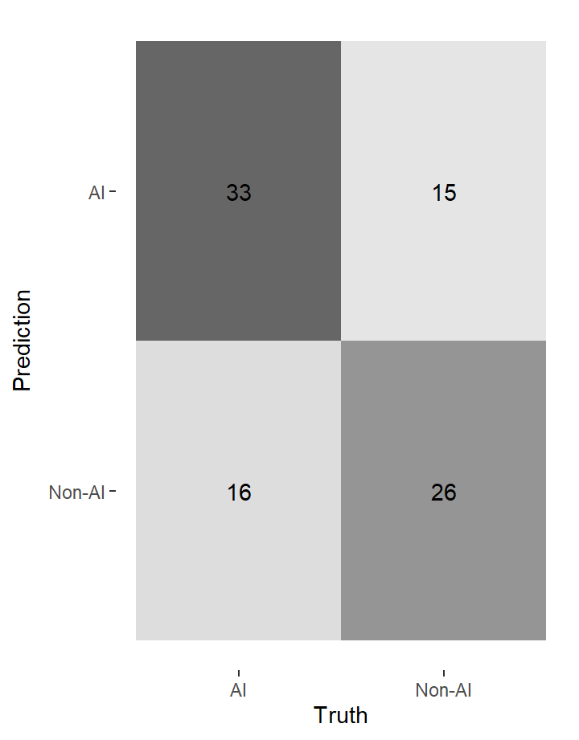

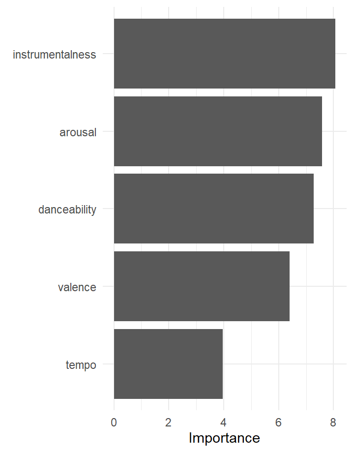

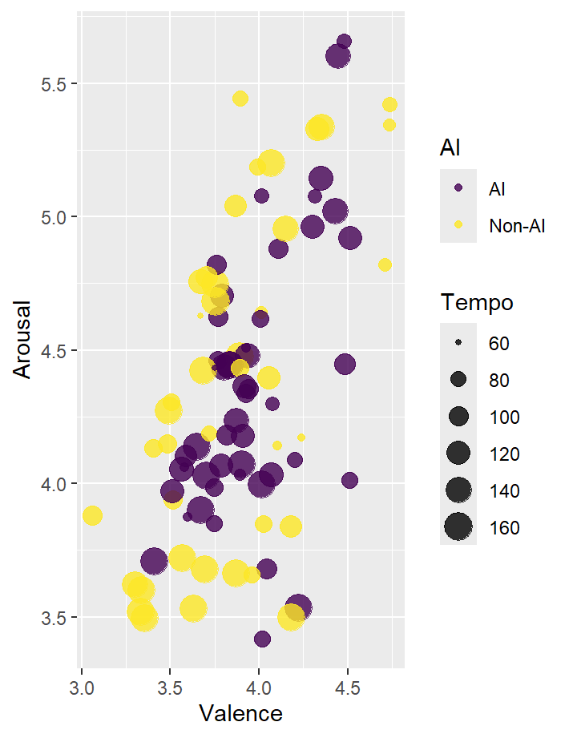

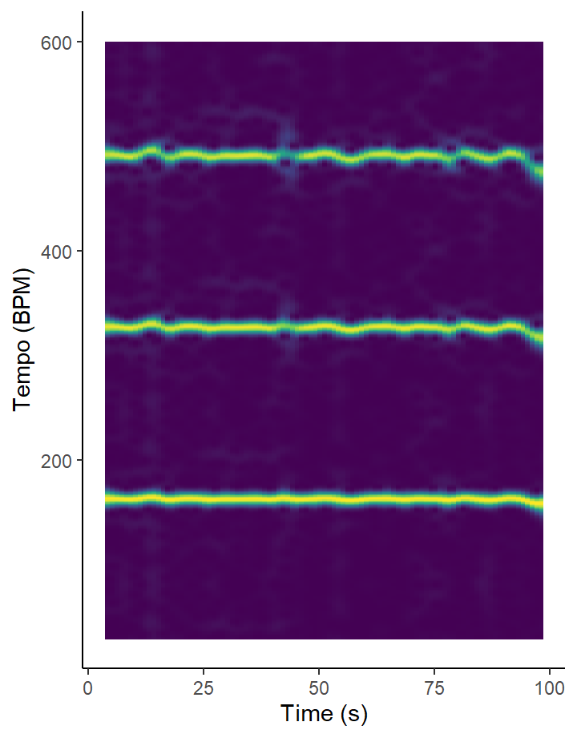

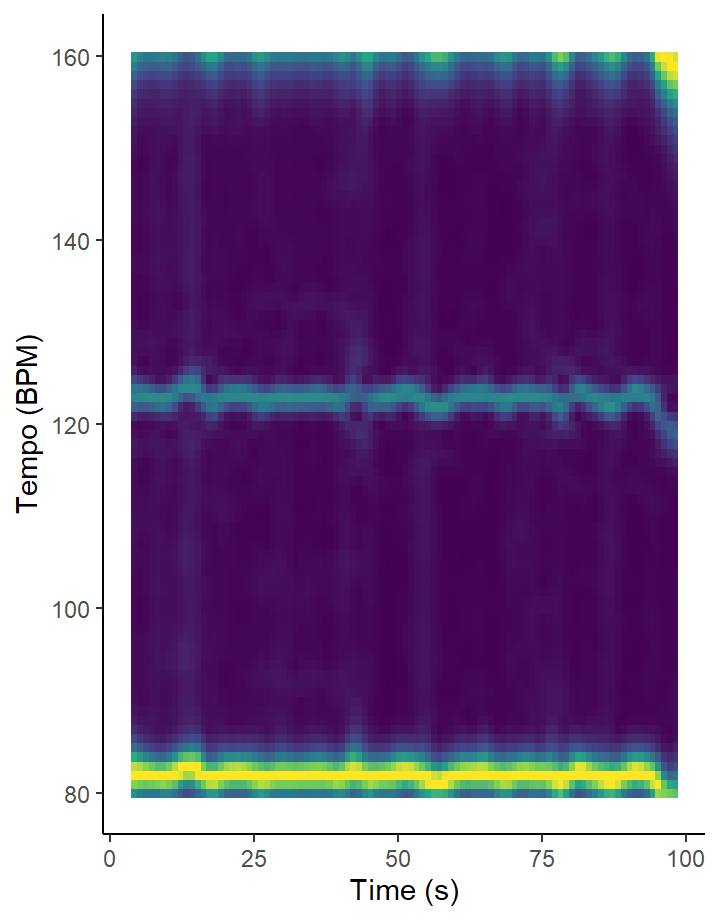

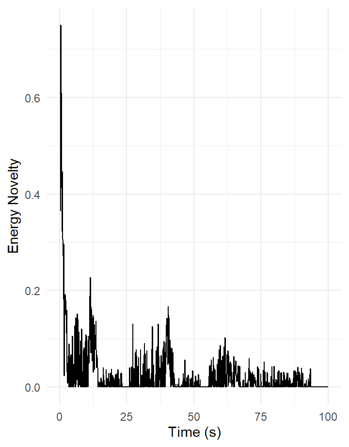

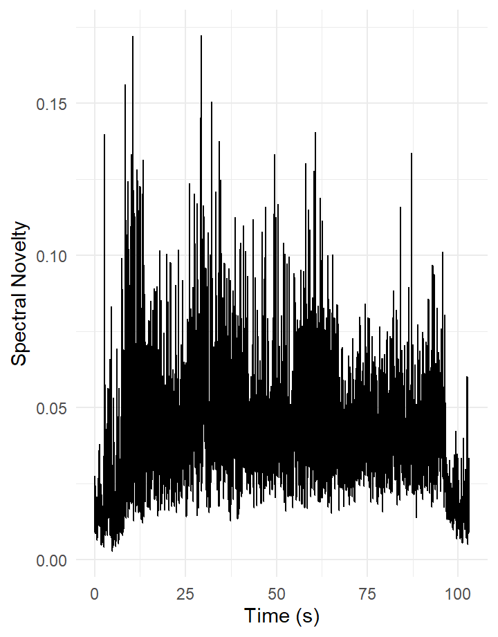

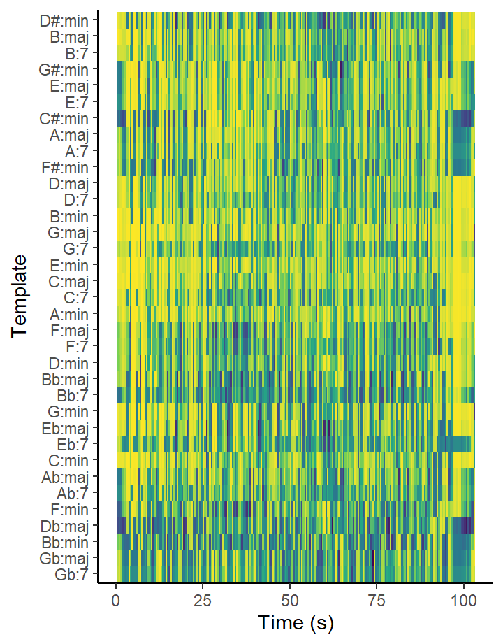

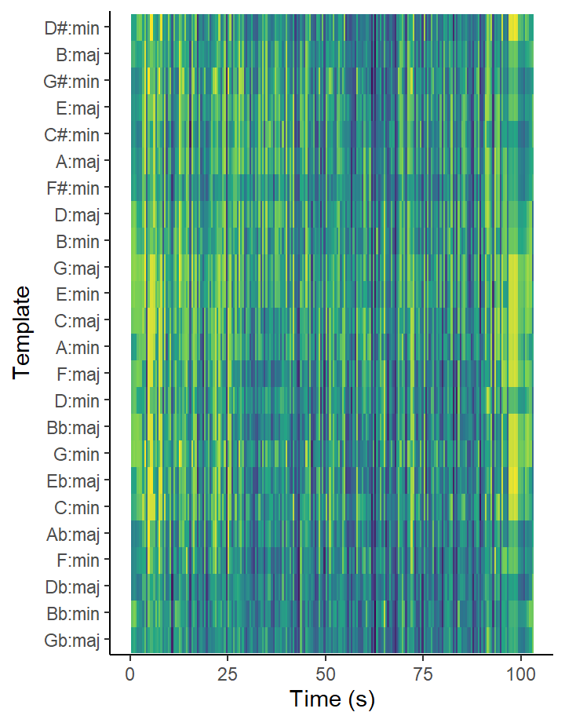

[7 more figures not shown]

### Hierarchical clustering

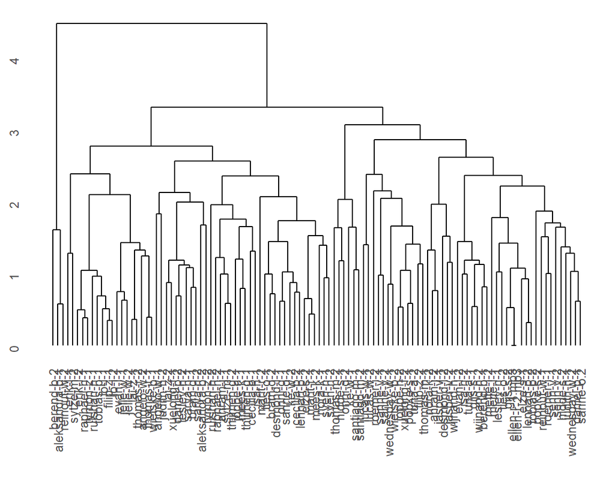

[interactive chart not shown]

One notable observation is the frequent occurrence of instances where two tracks by the same artist are clustered next to each other in the dendrogram. This could be indicative of the artist using similar production techniques, such as a consistent “vibe” or overall feel across their work. When artists produce multiple tracks, they might follow certain thematic or sonic patterns that contribute to their music having similar characteristics, such as tempo, rhythm, and mood.

Additionally, for AI-generated music, this pattern could suggest that the same prompt or model settings were used to produce the tracks. AI models often rely on specific input parameters or prompts, and slight variations of those prompts can yield outputs that still retain recognizable similarities in structure and feel. Therefore, when the same prompt is used repeatedly, it can cause AI-generated tracks to have similar musical characteristics, which could result in clustering them near each other in the dendrogram. This observation underscores the importance of production methods, whether human or AI, in shaping the final sound and how those methods can influence the clustering of tracks.

### Ai vs non ai table

|  | filename | ai |
| --- | --- | --- |
| 1 | ahram-j-1 | AI |
| 2 | ahram-j-2 | AI |
| 3 | aleksandra-b-1 | Non-AI |
| 4 | aleksandra-b-2 | AI |
| 5 | angelo-w-1 | Non-AI |
| 6 | angelo-w-2 | Non-AI |
| 7 | berend-b-1 | AI |
| 8 | berend-b-2 | AI |
| 9 | bram-d-1 | AI |
| 10 | bram-d-2 | AI |

[output cut: 80 more lines]

### Hierarchical clustering AI

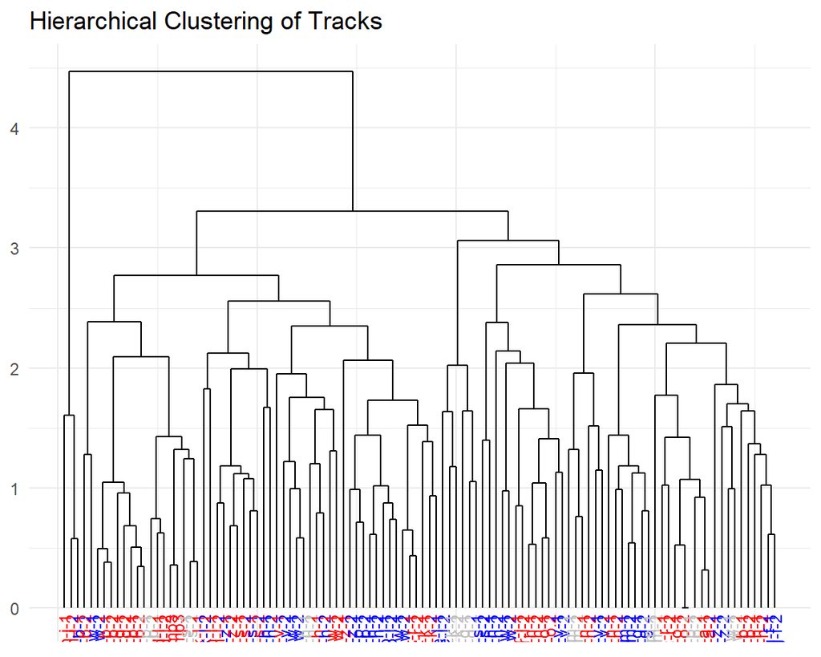

[interactive chart not shown]

### Heatmap

[interactive chart not shown]

```
          Truth
Prediction AI Non-AI
    AI     33     15
    Non-AI 16     26
```

### mosaic style

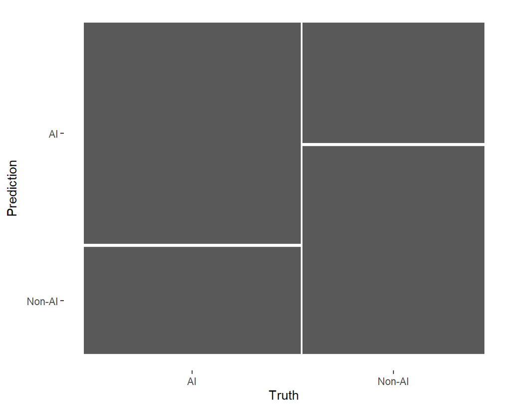

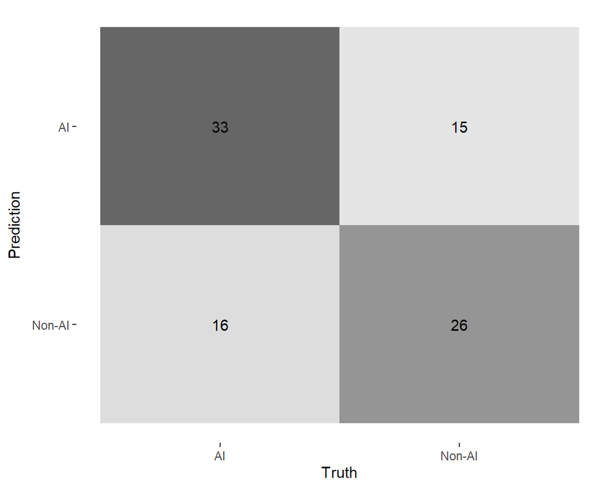

```
# A tibble: 2 × 3
  class  precision recall
  <fct>      <dbl>  <dbl>
1 AI         0.688  0.673
2 Non-AI     0.619  0.634
```

```
# A tibble: 2 × 3
  class  precision recall
  <fct>      <dbl>  <dbl>
1 AI         0.68   0.694
2 Non-AI     0.625  0.610
```

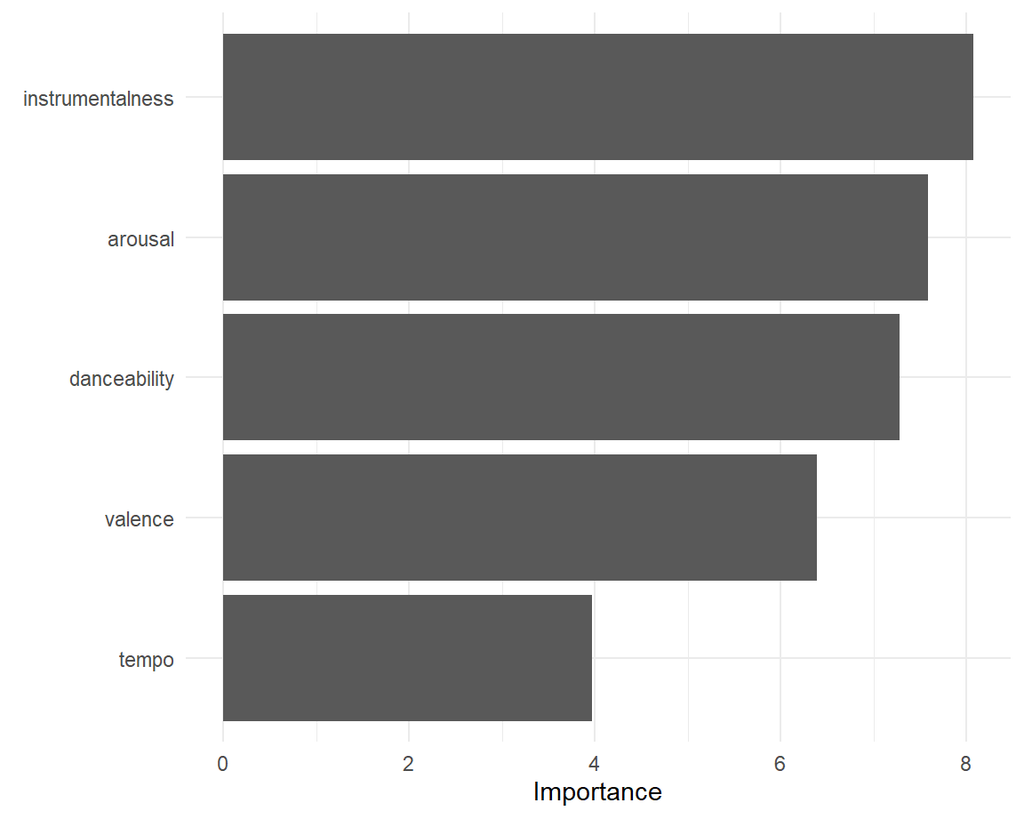

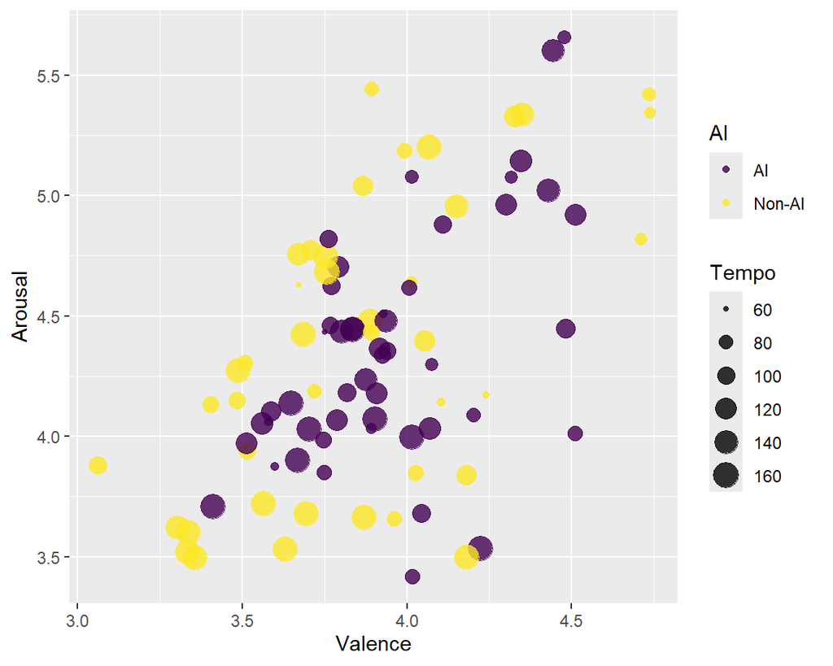

### Noncyclical Tempogram

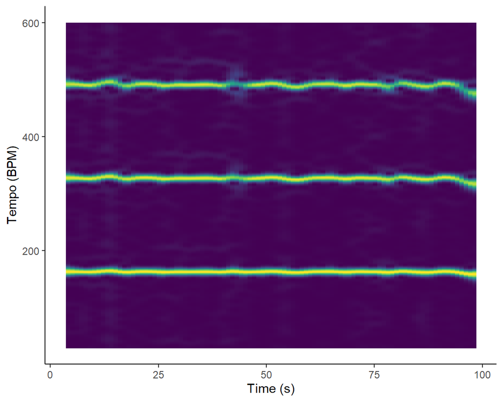

### Cyclical Tempogram

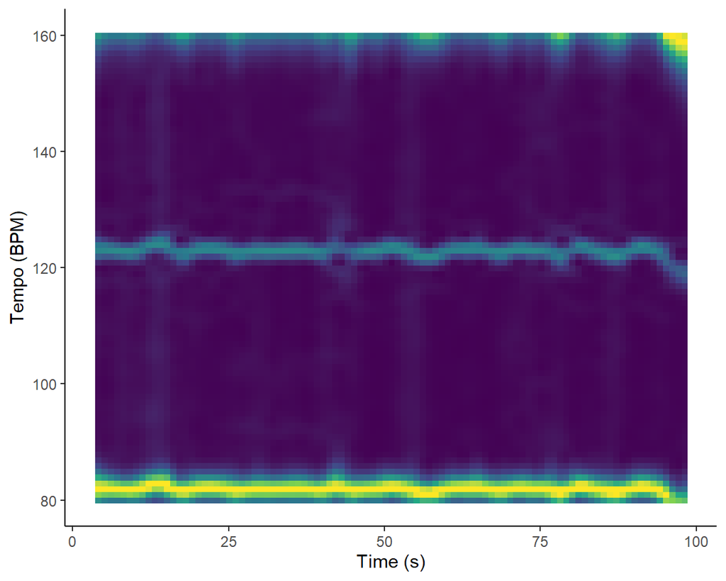

### Energy Novelty

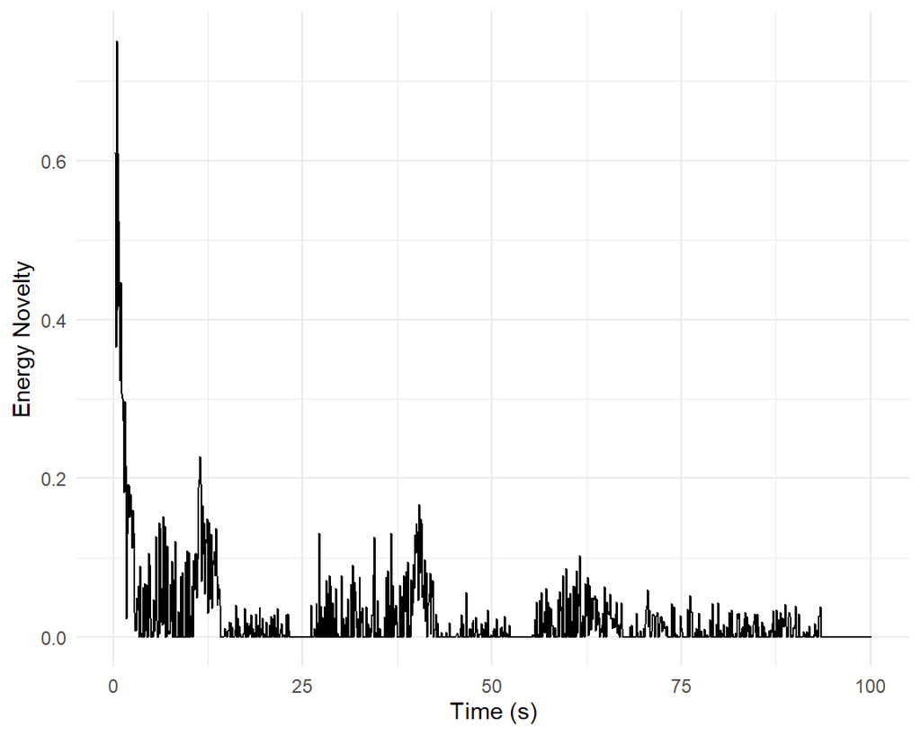

### Spectral Novelty

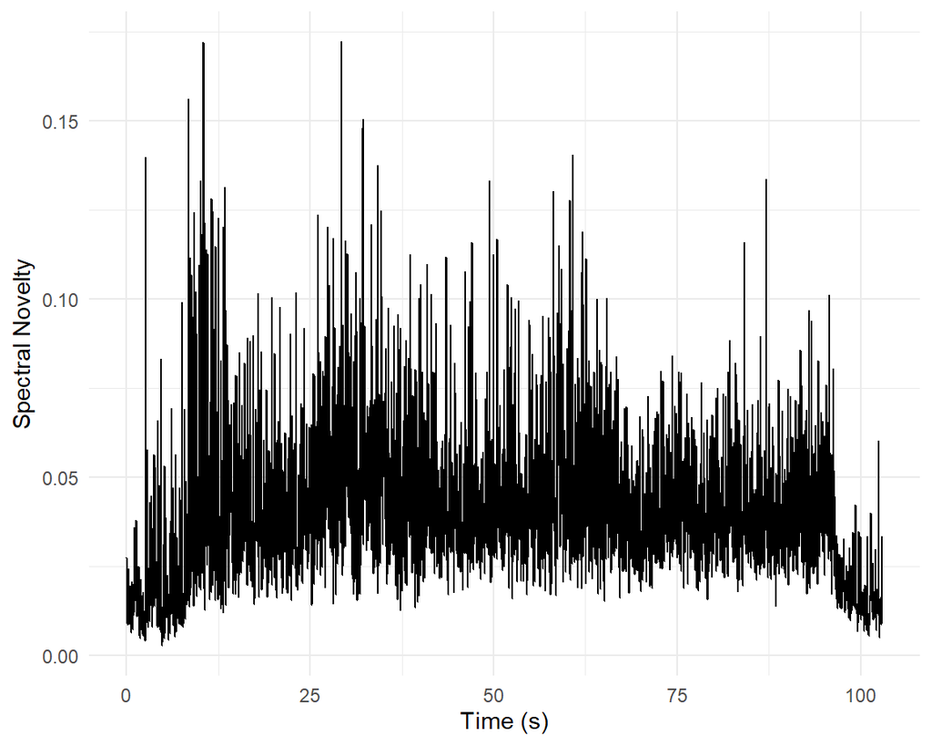

### Chordogram

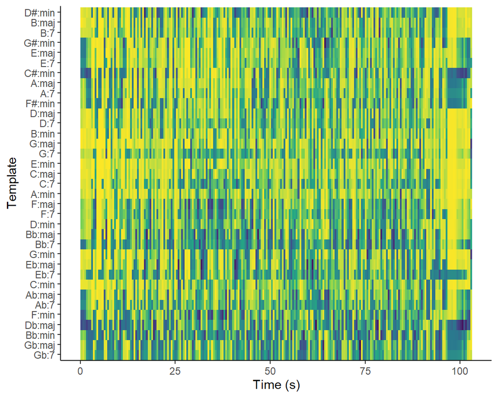

I am still waiting for the corpus to be updated with the music I submitted, so for this assignment, I will continue using Elze’s track (Elze_s_1) as my reference.

I’ve come to realize how much genre can affect a chordogram or really, any kind of spectral visualization. Since this is a grunge/alternative band, their use of heavy distortion introduces rich overtones and harmonics, making it harder to clearly distinguish between chords or even the key. The added harmonic content from distortion can blur the lines between different tonal centers, making chord recognition less precise.

### Keygram

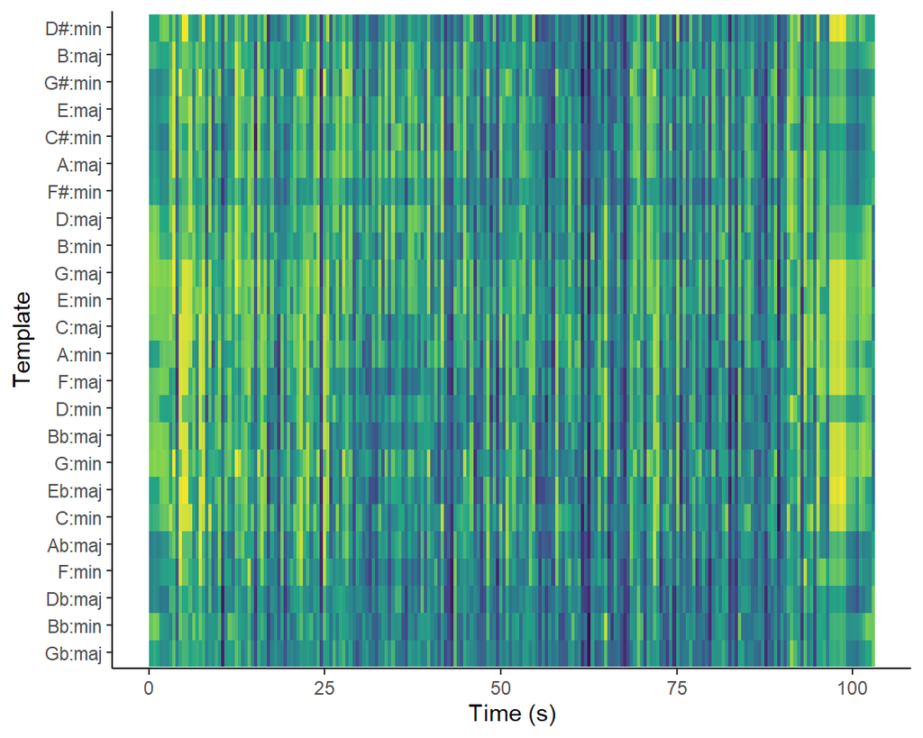

In this keygram, it seems to do a worse job at identifying the key, especially in this genre. The smooth variations in the keygram make it less visible when dealing with louder, more distorted, or droning music, all of which are defining characteristics of grunge. The heavy use of distortion and overtones likely introduces inconsistencies in key detection, resulting in a more blurred representation.

In contrast, the chromagram appears to be more effective at visualizing the key. As seen in the next section, I will place them side by side to highlight these differences.

### Combined

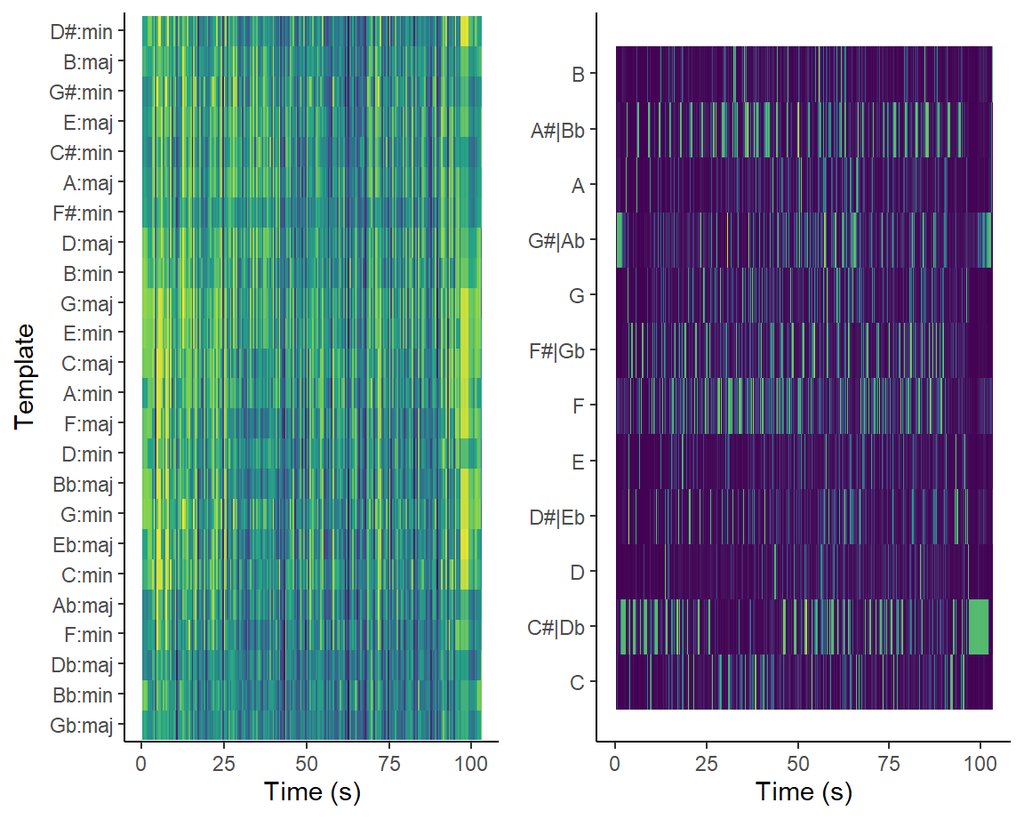

Overall, the challenges in key detection for grunge music stem from the genre’s heavy use of distortion, power chords, and tonal ambiguity. The extra overtones introduced by distortion create harmonics that confuse key detection algorithms, leading to instability in the keygram. Additionally, since power chords lack a clear major or minor identity, keygrams, which rely on full triads, struggle to establish a consistent key, causing fluctuations in the results. Lastly, the smoothing effect of keygrams further reduces their reliability in a genre where harmonic transitions are often blurred or undefined. In contrast, the chromagram proves to be a more effective tool for visualizing tonal centers, as it captures the raw pitch-class data without forcing a rigid key interpretation. This makes it a better choice for analyzing grunge and other heavily distorted music styles.

### Chromagram

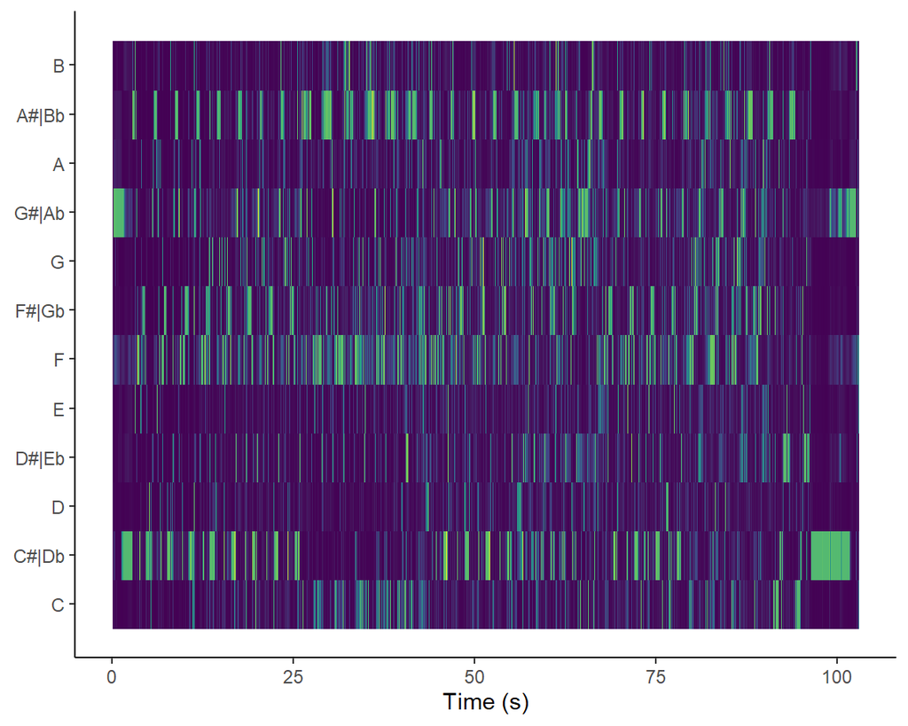

Unfortunately, just like last week, my music is still not in the class corpus, so I decided to analyze the track Elze_s_1 instead. While discussing the track with Elze, she informed me that it’s from her band, which plays alternative rock/grunge. This genre choice offers an interesting and distinct sonic palette, and through this analysis, I’ll explore the song’s harmonic and timbral elements to uncover how its structure is defined in music like alternative rock/grunge, starting with the chromagram to reveal the key it’s in.

The chromagram highlights the notes B♭ - C - D♭ - E♭ - F - G♭ - A♭ - (B♭), which corresponds to the B-flat minor scale. This suggests that the track is primarily in the key of B-flat minor, reinforcing a darker, more melancholic tonality.

### Chroma-based self-similarity

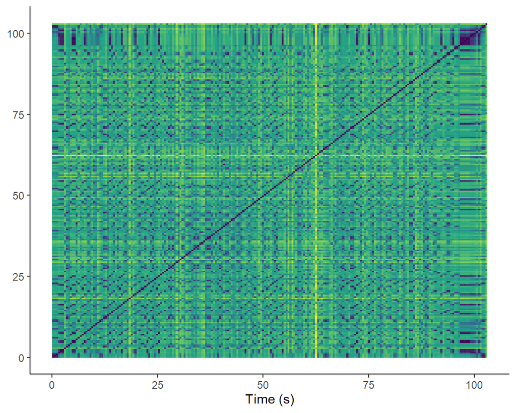

### Timbre-based self-similarity

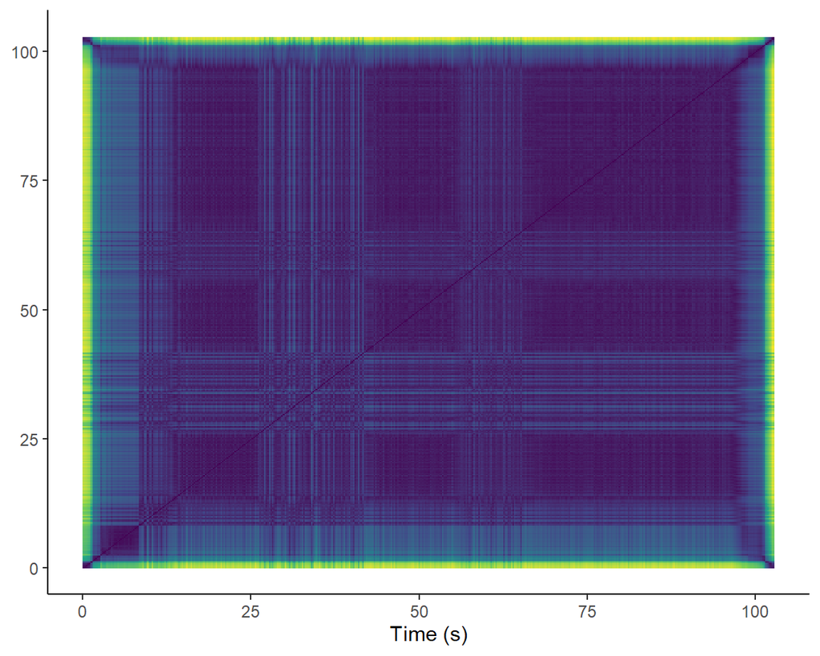

The timbre-based similarity matrix reveals structure more clearly than the chroma-based matrix, suggesting that textural changes drive the song’s form, which is common in alternative rock/grunge. Key moments include 8s, where the drums enter, and 26s, where the guitar fades and the drums become more relaxed for the verse. The chroma matrix shows less variation, indicating that harmony remains stable while instrumentation and mix shape the song’s sections. This highlights the role of timbre in defining musical form, especially in grunge and alt-rock, where dynamic shifts and raw textures are essential.

### Introduction

Unfortunately, due to uploading my files to the comment section of the first homework assignment, my songs did not appear in the class corpus. I attempted to run my tracks through Essentia using Python, but encountered installation errors. Therefore, for this assignment, I will focus on comparing the class corpus with the AI Song Contest (AISC) dataset.

My mini research will focus on identifying the outliers in both datasets, particularly in the feature of danceability, while also considering potential factors such as tempo and instrumentalness. I will begin by analyzing these outliers based on the perceived values of these features, without listening to the tracks. After identifying the outliers, I will then listen to the tracks and compare my subjective interpretation of these features to the results from Essentia. This process will allow me to explore how well the feature extraction methods align with my own musical perceptions and whether the outliers identified by Essentia fit within a broader musical context.

### Visualizing the Class Corpus

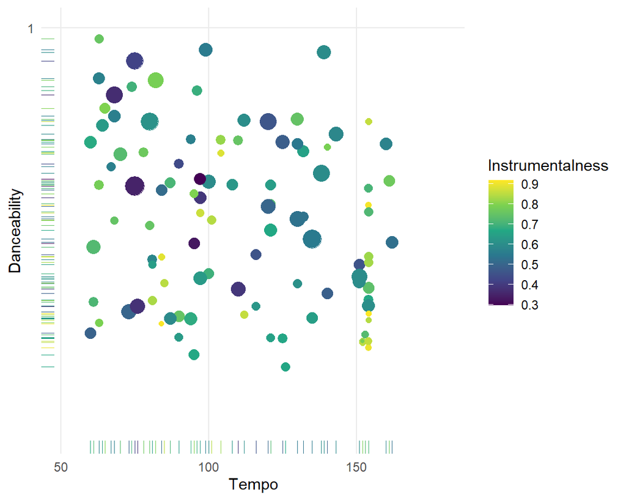

[interactive chart not shown]

This scatter plot visualizes the **Class Corpus** dataset, focusing on the relationship between **tempo** (x-axis) and **danceability** (y-axis), with **instrumentalness** represented by color.

### Visualizing the AI Song contest

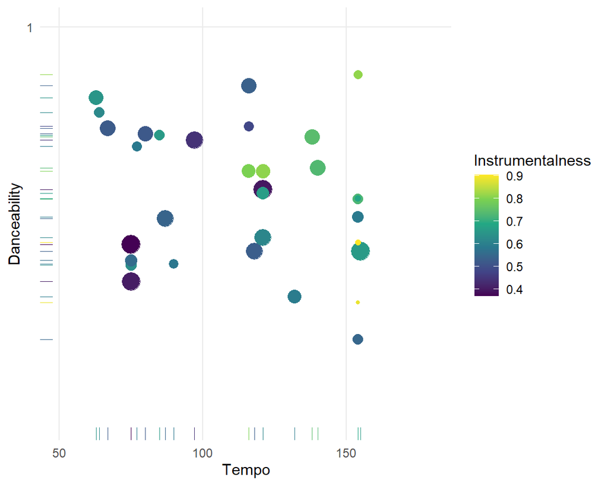

[interactive chart not shown]

This scatter plot visualizes the **AI Song Contest** 2024 dataset, displaying the relationship between **tempo** (x-axis) and **danceability** (y-axis), with **instrumentalness** represented by color.

### Exploring Danceability Across Datasets

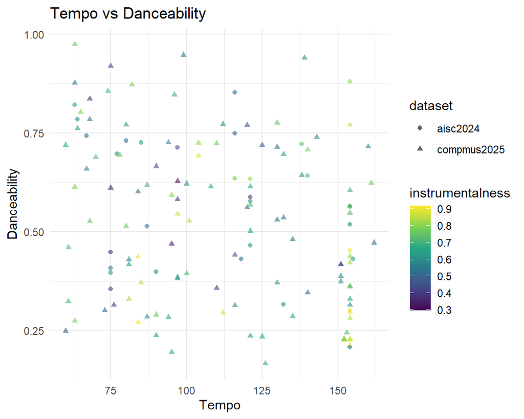

[interactive chart not shown]